# Group4-KKT,KYJ,KYR,SJH

We used time-series and forecast packages to forecast future temperature by using past day’s patterns. We made a graph of forecasted data and merged with the graph of actual temperature data measured between 2014 and 2020 May. Then we compared those two graphs and saw the difference between them.

```r
library(forecast)
```

#South Korea - Seoul

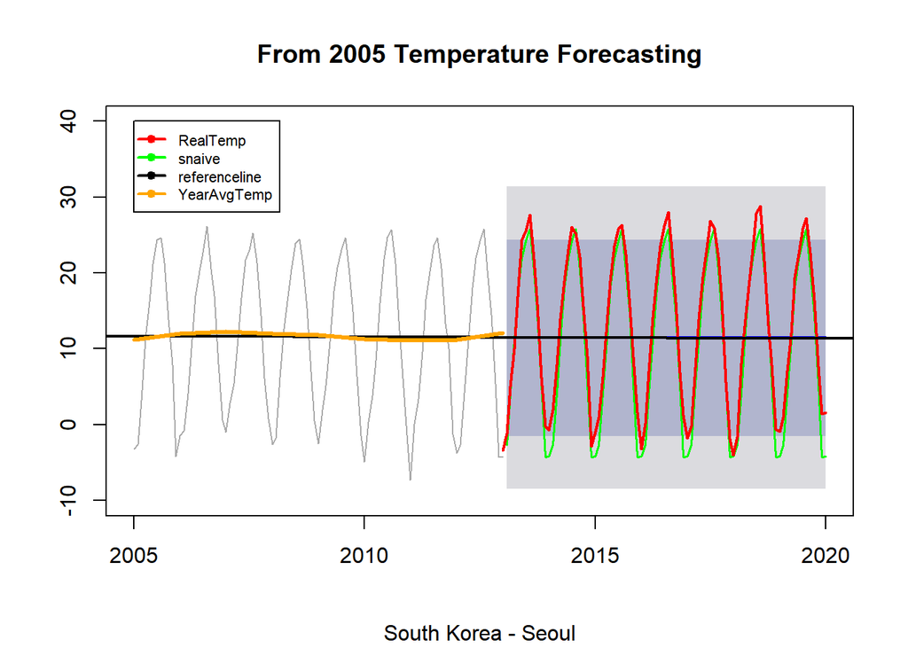

```r
#Kim Yerin
#I got the real temperature in Seoul data from the Meteorological Administration. #(https://data.kma.go.kr/stcs/grnd/grndTaList.do?pgmNo=70)
#Read Seoul's real temperature data and save it into 'RealTempInSeoul'
RealTempInSeoul <- read.csv("SeoulTemp.csv")
#Since this is the Korea data I change columnnames to English to work in R.
colnames(RealTempInSeoul) <- c("dt","location","average","low","high")
#Make the dataframe with selecting needed column 'dt', 'average' and mutating columns 'when'(by changing the data type to date from dt column), 'year'(by admitting the year function of lubridate to when column).
RealTempInSeoul <- RealTempInSeoul %>% select(dt, average) %>% mutate(When = as.Date(dt, format="%Y-%m-%d"), year=year(When))

#Extract only Seoul's climate data of 'yclean' from 2005 and save it in 'seoul'.
seoul <- yclean %>% filter(City=="Seoul" & year >= 2005) %>% na.omit()
#Summarise average temperature of each year and save the summary into 'seoul_avgtemp'.
seoul_avgtemp <- summarise(group_by(seoul,year),avg_temp = mean(AverageTemperature))
#Make the 'avg_temp' column of 'seoul_avgtemp' dataframe into time series and save it as 'seoul_.ts'. I made a time series in yearly frequency to draw the annual average temperature line and inspect the overall increase.
seoul_.ts <- ts(seoul_avgtemp$avg_temp, start = 2005, end = 2013, frequency = 1)
#Make the 'AverageTemperature' column of 'seoul' dataframe into time series and save it as 'seoul.ts'. I made a time series in monthly frequency from 2005 to 2013 to find seasonality.
seoul.ts <- ts(seoul$AverageTemperature, start = 2005, end = 2013, frequency = 12)

#Make 'average' column of 'RealTempInSeoul' dataframe and save it as 'RSeoul.ts' as well.
RSeoul.ts <- ts(RealTempInSeoul$average, start = 2013, end = 2020, frequency = 12)

#I used average and seasonal naive model for forecasting. Since our time series have seasonal repetition, we made the time series in monthly frequency.**
seoul.train <- window(seoul.ts, end = 2013)
seoul.average <- meanf(seoul.train, h = 84)
seoul.snaive <- snaive(seoul.train, h = 84)

#Plotting graph of past temperature and average of all observations for all future predictions
plot(seoul.average, ylim=c(-10,40), col = "dark grey",main="From 2005 Temperature Forecasting", sub="South Korea - Seoul")
#Draw a line of Seasonal naive in green
lines(seoul.snaive$mean, col = "green", lty = 1, lwd=1.5)
#Add the real temperature data between 2014 and 2020 in red
lines(RSeoul.ts, col = "red", lty = 1, lwd =2)
#Draw a linear regression of past temperature data 'seoul' in black
abline(lm(avg_temp~year, data = seoul_avgtemp), col = "black", lwd=2)
#Add annual average temperature of past temperature data in orange.
lines(seoul_.ts, col = "orange", lwd = 3)
#Show the legend of each graph element

legend(2005,40,c("RealTemp","snaive","referenceline","YearAvgTemp"), cex=0.7, col=c("red","green","black","orange"),pch=1, lty=1,lwd=2)
```

**) Reason why we made the time series in monthly frequency: At first, we try to group by the year and drew the line graph of temperature from 1980 to 2013 and predict how the climate would be from 2014 to 2020. but when we code this and use the seasonal naive method, the line appear as linear, which makes us hard to compare our prediction with real data. As the seasonality is represented monthly, we think that not grouping by the year and drew the graph by the month let us show the seasonality more clearly and compare with real data easily. Then, the bin width of x-axis became too small to inspect the prediction, so we limit the x value start from January 2005.

1. Comparing our prediction and the real temperature data: There is no significant difference between predicted temperature(green graph) and real temperature(red graph) in Seoul. Since there was no special industrial events or disasters to change the climate in Seoul between 2013 and 2020.

#China-Shanghai

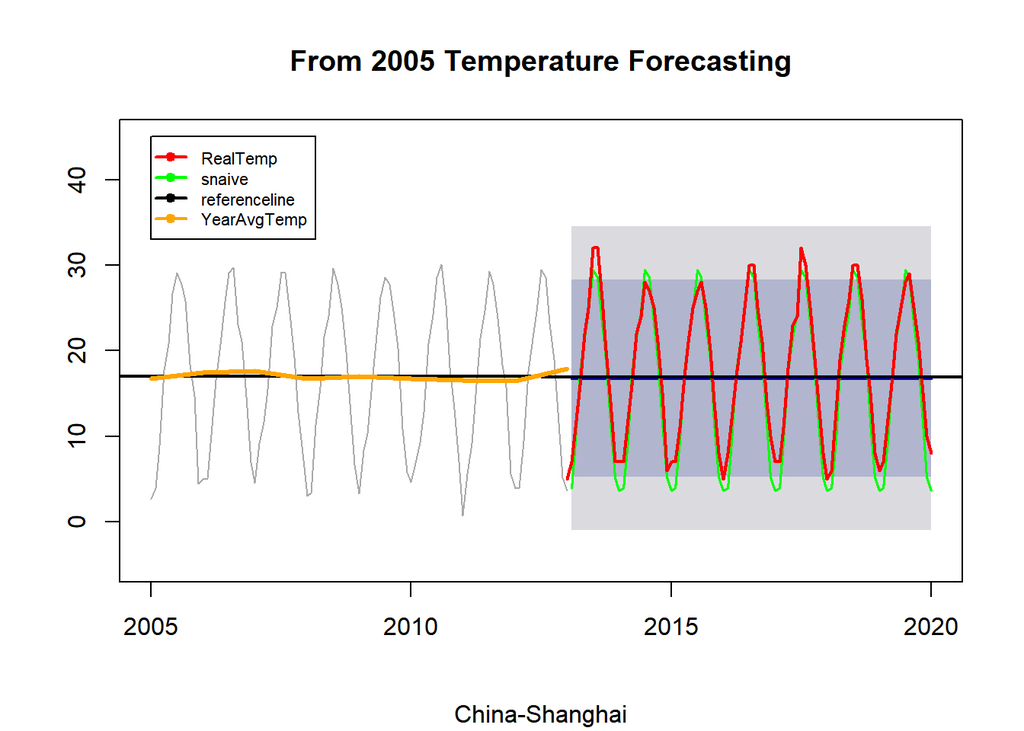

```r
#Kim Yerin
#I got the real temperature in Shanghai data from 'timeanddate' website.
#(https://www.timeanddate.com/weather/china/shanghai/historic?month=2&year=2014)
#Read Shanghai's real temperature data and save it into 'RealTempInShanghai'
RealTempInShanghai <- read.csv("ShanghaiTemp.csv")
#Make the dataframe with mutating columns 'when'(by changing the data type to date from dt column), 'year'(by admitting the year function of lubridate to when column).
RealTempInShanghai <- RealTempInShanghai %>% mutate(When = as.Date(dt, format="%Y-%m-%d"), year=year(When))

#Extract only Shanghai's climate data of 'yclean' from 2005 and save it in 'shanghai'.
shanghai <- yclean %>% filter(City=="Shanghai" & year >= 2005) %>% na.omit()
#Summarise average temperature of each year and save the summary into 'shanghai_avgtemp'.
shanghai_avgtemp <- summarise(group_by(shanghai,year),avg_temp = mean(AverageTemperature))
#Make the 'avg_temp' column of 'shanghai_avgtemp' dataframe into time series and save it as 'shanghai_.ts'. I made a time series in yearly frequency to draw the annual average temperature line and inspect the overall increase.
shanghai_.ts <- ts(shanghai_avgtemp$avg_temp, start = 2005, end = 2013, frequency = 1)

#Make the 'AverageTemperature' column of 'shanghai' dataframe into time series and save it as 'shanghai.ts'. I made a time series in monthly frequency from 2005 to 2013 to find seasonality.
shanghai.ts <- ts(shanghai$AverageTemperature, start = 2005, end = 2013, frequency = 12)

#Make 'avgtemp' column of 'RealTempInShanghai' dataframe and save it as 'RShanghai.ts' as well.
RShanghai.ts <- ts(RealTempInShanghai$avgtemp, start = 2013, end = 2020, frequency = 12)

#I used average and seasonal naive model for forecasting. Since our time series have seasonal repetition, we made the time series in monthly frequency.
shanghai.train <- window(shanghai.ts, end = 2013)
shanghai.average <- meanf(shanghai.train, h = 84)
shanghai.snaive <- snaive(shanghai.train, h = 84)

#Plotting graph of past temperature and average of all observations for all future predictions
plot(shanghai.average, ylim=c(-5,45), col = "dark grey",main="From 2005 Temperature Forecasting", sub="China-Shanghai")
#Draw a line of Seasonal naive in green
lines(shanghai.snaive$mean, col = "green", lty = 1, lwd=1.5)
#Add the real temperature data between 2014 and 2020 in red
lines(RShanghai.ts, col = "red", lty = 1, lwd =2)
#Draw a linear regression of past temperature data 'shanghai' in black
abline(lm(avg_temp~year, data = shanghai_avgtemp), col = "black", lwd=2)
#Add annual average temperature of past temperature data in orange.
lines(shanghai_.ts, col = "orange", lwd = 3)
#Show the legend of each graph element

legend(2005,45,c("RealTemp","snaive","referenceline","YearAvgTemp"), cex=0.7, col=c("red","green","black","orange"),pch=1, lty=1,lwd=2)
```

1. Comparing our prediction and the real temperature data: Not as much as Seoul, but our prediction(green graph) of Shanghai was also quite similar with the real temperature(red graph). Shanghai’s temperature seems to have small fluctuation, so the prediction was similar to the real temperature.

#Russia-Saint Petersburg

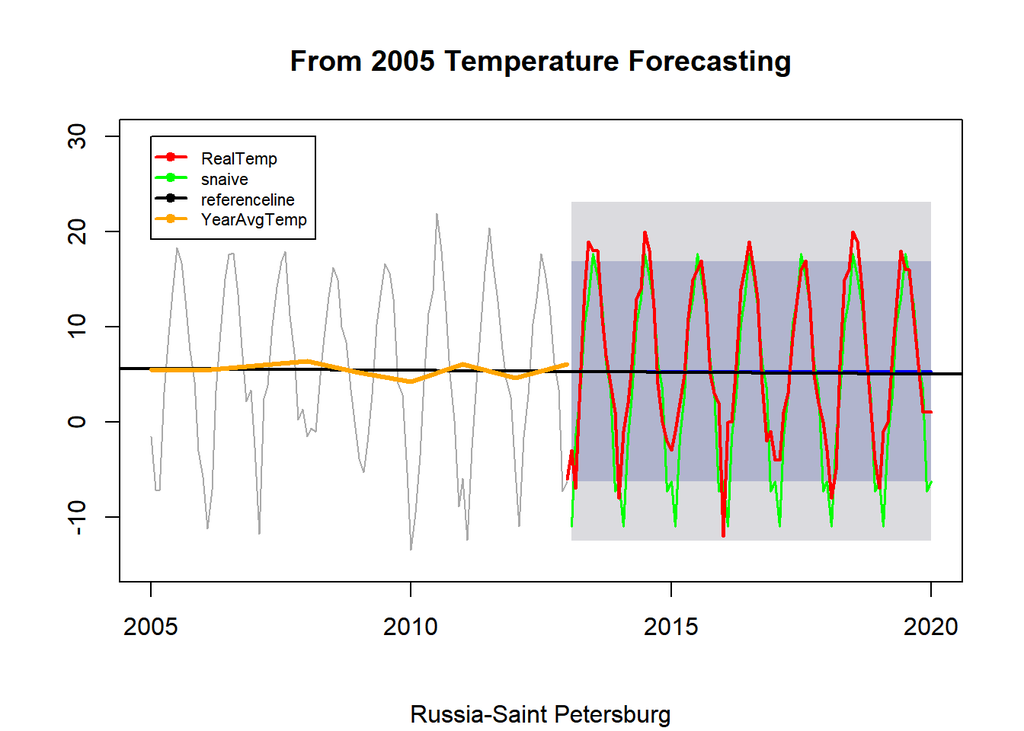

```r
#Kim Yerin
#I got the real temperature in Saint Petersburg data from 'timeanddate' website.
#(https://www.timeanddate.com/weather/russia/saint-peterburg/historic?month=6&year=2020)
#Read Saint Petersburg's real temperature data and save it into 'RealTempInSaint'
RealTempInSaint <- read.csv("Saint-PetersburgTemp.csv")
#Make the dataframe with mutating columns 'when'(by changing the data type to date from dt column), 'year'(by admitting the year function of lubridate to when column).
RealTempInSaint <- RealTempInSaint %>% mutate(When = as.Date(dt, format="%Y-%m-%d"), year=year(When))

#Extract only Saint's climate data of 'yclean' from 2005 and save it in 'saint'.
saint <- yclean %>% filter(City=="Saint Petersburg" & year >= 2005) %>% na.omit()
#Summarise average temperature of each year and save the summary into 'saint_avgtemp'.
saint_avgtemp <- summarise(group_by(saint,year),avg_temp = mean(AverageTemperature))
#Make the 'avg_temp' column of 'saint_avgtemp' dataframe into time series and save it as 'saint_.ts'. I made a time series in yearly frequency to draw the annual average temperature line and inspect the overall increase.
saint_.ts <- ts(saint_avgtemp$avg_temp, start = 2005, end = 2013, frequency = 1)

#Make the 'AverageTemperature' column of 'saint' dataframe into time series and save it as 'saint.ts'. I made a time series in monthly frequency from 2005 to 2013 to find seasonality.
saint.ts <- ts(saint$AverageTemperature, start = 2005, end = 2013, frequency = 12)

#Make 'avgtemp' column of 'RealTempInSaint' dataframe and save it as 'RSaint.ts' as well.
RSaint.ts <- ts(RealTempInSaint$avgtemp, start = 2013, end = 2020, frequency = 12)

#I used average and seasonal naive model for forecasting. Since our time series have seasonal repetition, we made the time series in monthly frequency.
saint.train <- window(saint.ts, end = 2013)
saint.average <- meanf(saint.train, h = 84)
saint.snaive <- snaive(saint.train, h = 84)

#Plotting graph of past temperature and average of all observations for all future predictions
plot(saint.average, ylim=c(-15,30), col = "dark grey",main="From 2005 Temperature Forecasting", sub="Russia-Saint Petersburg")
#Draw a line of Seasonal naive in green
lines(saint.snaive$mean, col = "green", lty = 1, lwd=1.5)
#Add the real temperature data between 2014 and 2020 in red
lines(RSaint.ts, col = "red", lty = 1, lwd =2)
#Draw a linear regression of past temperature data 'saint' in black
abline(lm(avg_temp~year, data = saint_avgtemp), col = "black", lwd=2)
#Add annual average temperature of past temperature data in orange.
lines(saint_.ts, col = "orange", lwd = 3)

#Show the legend of each graph element
legend(2005,30,c("RealTemp","snaive","referenceline","YearAvgTemp"), cex=0.7, col=c("red","green","black","orange"),pch=1, lty=1,lwd=2)
```

1. Comparing our prediction and the real temperature data: The prediction graph(green) meets quite well with the real temperature graph(red) in the upper part, but not in the lower part. So, we predicted well in summer months, but the real temperature is much higher than expected in winter months.

#Rio de Janeiro Forecasting

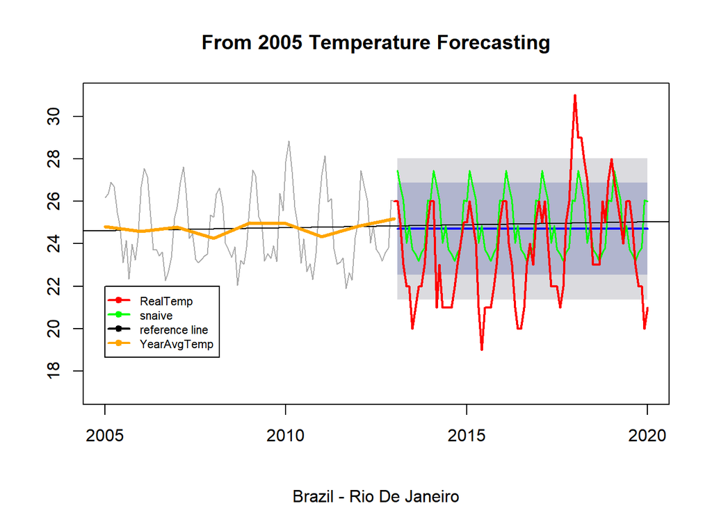

```r
#KIM Yoon Ji
#Read Rio de Janeiro's real temperature data and save it into 'rio_real'
rio_real <- read.csv("Rio_Temp_2014_2020.csv")

#Extract only "Rio de Janeiro's climate data of 'yclean' from 2005 and save it in 'rio'. Summarise average temperature of each year save the summary into 'rio_avgtemp'. Then make the 'AverageTemperature' column of 'rio' dataframe into time series and save it as 'rio.ts'. We made a time series in monthly frequency from 2005 to 2013.
rio <- yclean %>% filter(City=="Rio De Janeiro" & year >= 2005) %>% na.omit()
rio_avgtemp <- summarise(group_by(rio, year), avg_temp = mean(AverageTemperature))
rio.ts <- ts(rio$AverageTemperature, start = 2005, end = 2013, frequency = 12)

#Make 'AverageTemperature' column of 'rio.real' dataframe and save it as 'Rrio.ts' as well.
Rrio.ts <- ts(rio_real$AverageTemperature, start = 2013, end = 2020, frequency = 12)

#I used average and seasonal naive model for forcasting, since our time series have seasonal repitition because we made the time series in monthly frequency.
rio.train <- window(rio.ts, end = 2013)
rio.average <- meanf(rio.train, h = 84)
rio.snaive <- snaive(rio.train, h = 84)


plot(rio.average, xlim = c(2005, 2020), ylim = c(17,31), main = "From 2005 Temperature Forecasting", sub = "Brazil - Rio De Janeiro", col = "dark grey") #Plotting graph of past temperature and average of all observations for all future predictions
lines(rio.snaive$mean, col = "green", lty = 1, lwd = 1.5) #Draw a line of Snaive in green
abline(lm(AverageTemperature~year, data = rio), col = "black") #draw a linear regression of past temperature data 'rio' in black.
lines(Rrio.ts, col = "red", lwd = 2) #Add the real temperature data between 2014 and 2020 in red.
lines(rio_avgtemp, col = "orange", lwd = 3) #Add annual average temperature of past temperature data in orange.
legend(2005,22, c("RealTemp", "snaive", "reference line", "YearAvgTemp"), cex = 0.7, col = c("red", "green", "black", "orange"), pch = 1, lty = 1, lwd = 2) #Show the legend of each graph element.
```

The real data was usually lower than expeected, but higher than the expected climate only in 2018. This can mean that Rio?셲 climate has many fluctuation and differs from year to year, so its prediction missed with the real temperature.

#Montreal Forecasting

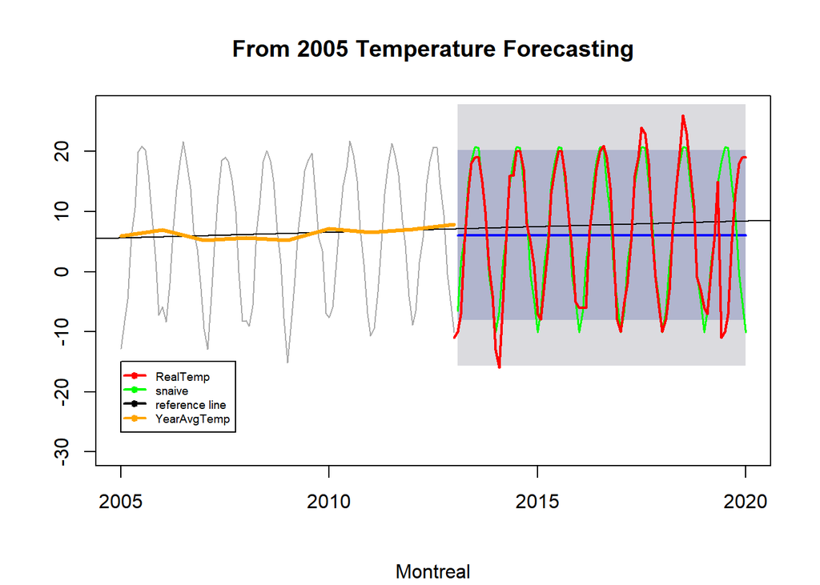

```r
#Kim Yoon Ji
#Read Montreal's real temperature data and save it into 'montreal_real'
montreal_real <- read.csv("Montreal_Temp_2014_2020.csv")

#Extract only "Rio de Janeiro's climate data of 'yclean' from 2005 and save it in 'montreal'. Summarise average temperature of each year save the summary into 'montreal_avgtemp'. Then make the 'AverageTemperature' column of 'montreal' dataframe into time series and save it as 'montreal.ts'. We made a time series in monthly frequency from 2005 to 2013.
montreal <- yclean %>% filter(City=="Montreal" & year >= 2005) %>% na.omit()
montreal_avgtemp <- summarise(group_by(montreal, year), avg_temp = mean(AverageTemperature))
montreal.ts <- ts(montreal$AverageTemperature, start = 2005, end = 2013, frequency = 12)

#Make 'AverageTemperature' column of 'montreal.real' dataframe and save it as 'Rmonreal.ts' as well.
Rmontreal.ts <- ts(montreal_real$AverageTemperature, start = 2013, end = 2020, frequency = 12)

#I used average and seasonal naive model for forcasting, since our time series have seasonal repitition because we made the time series in monthly frequency.
montreal.train <- window(montreal.ts, end = 2013)
montreal.average <- meanf(montreal.train, h = 84)
montreal.snaive <- snaive(montreal.train, h = 84)

plot(montreal.average, xlim = c(2005, 2020), ylim = c(-30,27), main = "From 2005 Temperature Forecasting", sub = "Montreal", col = "dark grey") #Plotting graph of past temperature and average of all observations for all future predictions
lines(montreal.snaive$mean, col = "green", lty = 1, lwd = 1.5) #Draw a line of Snaive in green
abline(lm(AverageTemperature~year, data = montreal), col = "black") #draw a linear regression of past temperature data 'montreal' in black.
lines(Rmontreal.ts, col = "red", lwd = 2)  #Add the real temperature data between 2014 and 2020 in red.
lines(montreal_avgtemp, col = "orange", lwd = 3) #Add annual average temperature of past temperature data in orange.
legend(2005,-15, c("RealTemp", "snaive", "reference line", "YearAvgTemp"), cex = 0.6, col = c("red", "green", "black", "orange"), pch = 1, lty = 1, lwd = 2) #Show the legend of each graph element.
```